# First Case Study

## 4.) Compute the median alcohol content and international bitterness unit for each state. Plot a bar chart to compare.

```
## No summary function supplied, defaulting to `mean_se()`
```

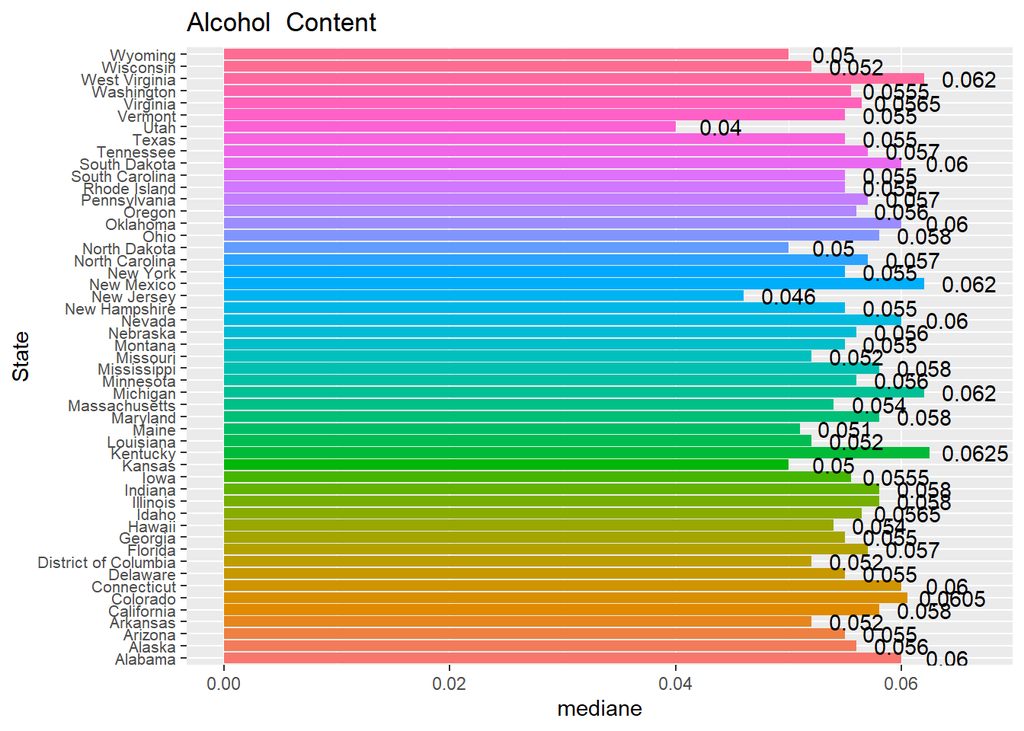

```r
## Compute and plot the median alcohol content by each state.

BB_merge_final <- BB_merge %>% group_by(State) %>% mutate(median_ABV = median(ABV,na.rm = TRUE))

## Plot a bar chart for median ABV.

BB_merge %>%filter(!is.na(State_Name)) %>%group_by(State_Name) %>% summarise(median_ABV = median(ABV, na.rm= T)) %>% ggplot(aes(x=State_Name, y= median_ABV, fill = State_Name)) +geom_bar(stat = "Summary", position = "dodge") + geom_text(aes(label = median_ABV), nudge_y = 0.004)+ ggtitle("Alcohol  Content") + xlab('State')+ ylab('mediane') + theme(legend.position = "none", axis.text.y = element_text(size=8)) + coord_flip()
```

```
## No summary function supplied, defaulting to `mean_se()`
```

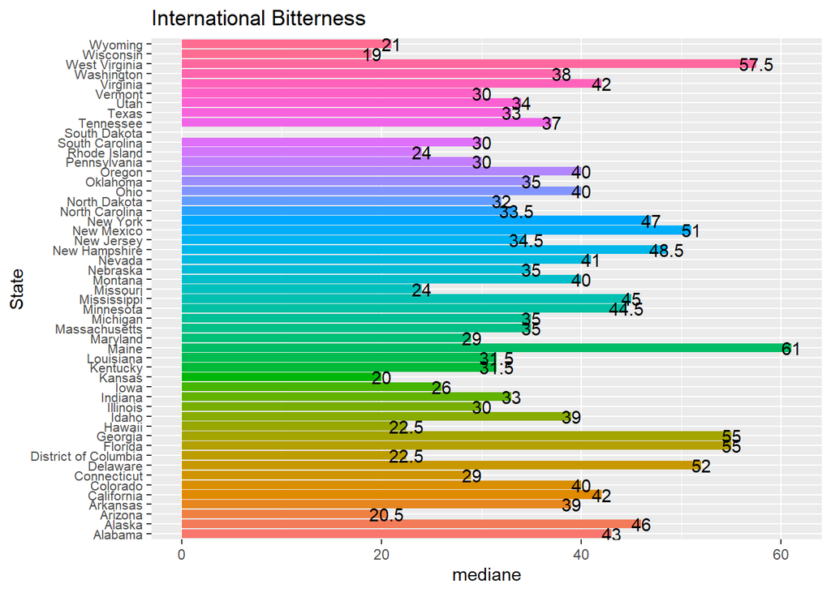

```r
##  Compute and plot the median international bitterness unit by each state.
BB_merge_final <- BB_merge_final %>% group_by(State) %>% mutate(median_IBU = median(IBU,na.rm = TRUE))

## Plot a bar chart for median IBU.
BB_merge %>% filter(!is.na(State_Name)) %>% group_by(State_Name) %>% summarise(median_IBU = median(IBU, na.rm= T)) %>% ggplot(aes(x=State_Name, y= median_IBU, fill = State_Name)) +
  geom_bar(stat = "Summary", position = "dodge") + geom_text(aes(label = median_IBU), nudge_y =  0.004)+ ggtitle("International Bitterness") + xlab('State')+ ylab('mediane')  + theme(legend.position = "none", axis.text.y = element_text(size=8)) + coord_flip()
```

## 5) Which state has the maximum alcoholic (ABV) beer? Which state has the most bitter (IBU) beer?

```r
BB_merge$State_Name[which.max(BB_merge$ABV)]
```

```
## [1] "Colorado"
```

```r
BB_merge$State_Name[which.max(BB_merge$IBU)]
```

```
## [1] "Oregon"
```

```
## No summary function supplied, defaulting to `mean_se()`
```

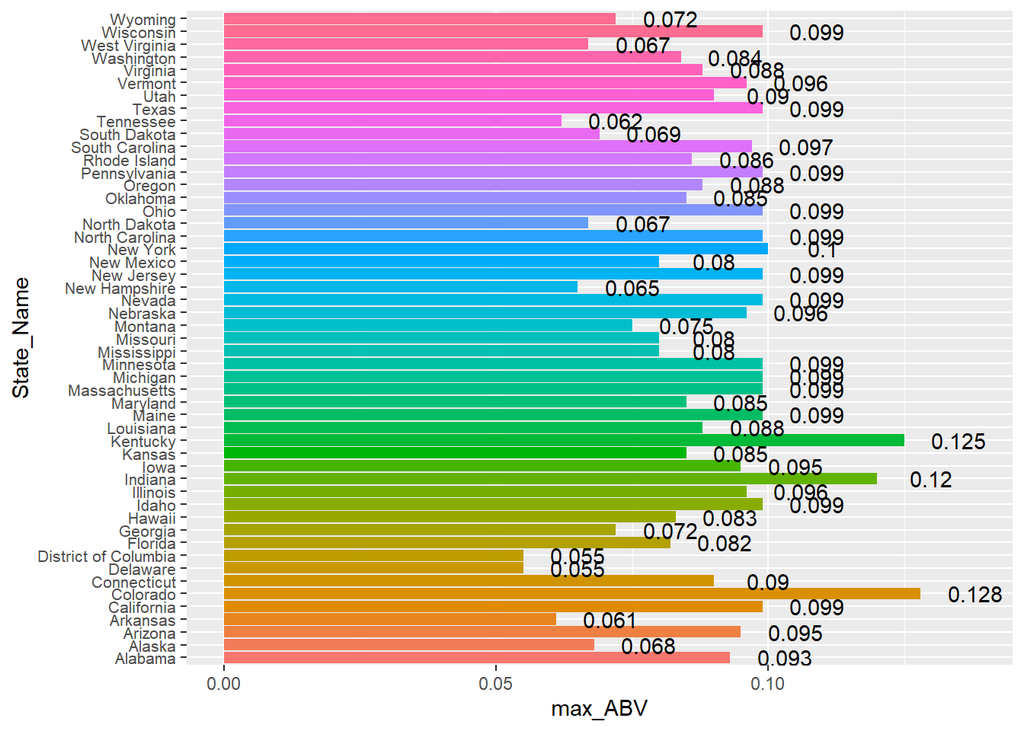

```r
BB_merge %>% filter(!is.na(State_Name))%>%  group_by(State_Name) %>% summarise(max_ABV = max(ABV, na.rm = T)) %>% ggplot(aes(x= max_ABV , y = State_Name, fill=State_Name)) +
   geom_bar(position='dodge',stat = 'summary') + geom_text(aes(label = max_ABV), nudge_x =  0.01) + theme(legend.position = "none", axis.text.y = element_text(size=8))
```

```
## No summary function supplied, defaulting to `mean_se()`
```

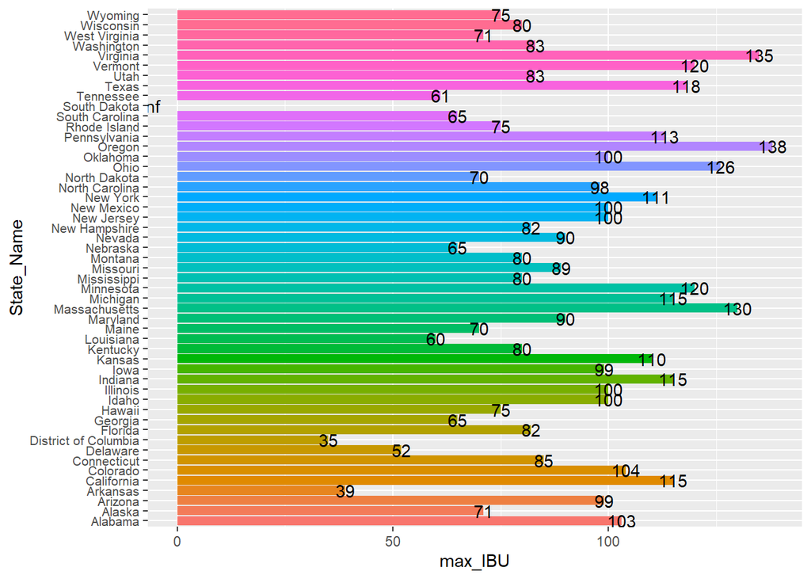

```r
BB_merge %>% filter(!is.na(State_Name)) %>% group_by(State_Name) %>% summarise(max_IBU = max(IBU, na.rm = T)) %>% ggplot(aes(x= max_IBU , y = State_Name, fill=State_Name)) +
  geom_bar(position='dodge',stat = 'summary') + geom_text(aes(label = max_IBU), nudge_x =  0.01) + theme(legend.position = "none", axis.text.y = element_text(size=8))
```

## Conclusion: Colorado and Oregon have the maximum alcoholic content and the most bitter beer

## 6) Comment on the summary statistics and distribution of the ABV variable.

```r
summary(BB_merge$ABV)
```

```
##    Min. 1st Qu.  Median    Mean 3rd Qu.    Max.    NA's
## 0.00100 0.05000 0.05600 0.05977 0.06700 0.12800      62
```

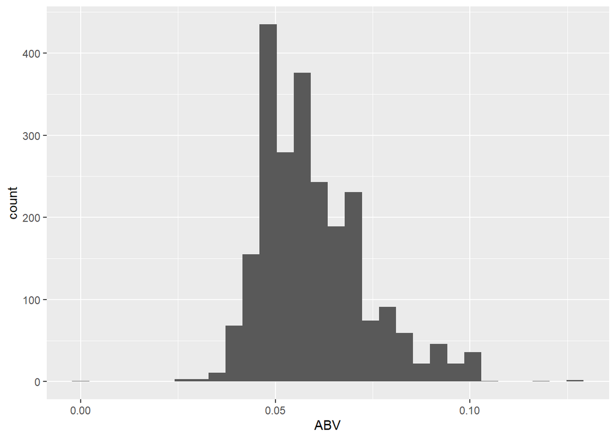

```r
BB_merge %>% ggplot(aes(x=ABV)) + geom_histogram()
```

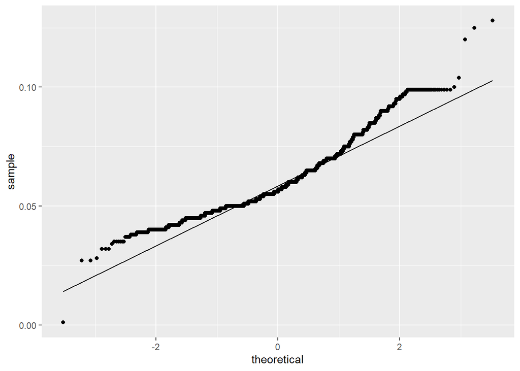

```r
BB_merge %>% ggplot(aes(sample = ABV)) + stat_qq()+stat_qq_line()
```

## 7) Is there an apparent relationship between the bitterness of the beer and its alcoholic content? Draw a scatter plot.Make your best judgment of a relationship and EXPLAIN your answer.

```r
BB_merge$scaledIBU <- scale(BB_merge$IBU)
BB_merge$scaledABV <- scale(BB_merge$ABV)
coef(lm(scaledIBU ~ scaledABV, data = BB_merge))
```

```
## (Intercept)   scaledABV
## -0.00693796  0.66891271
```

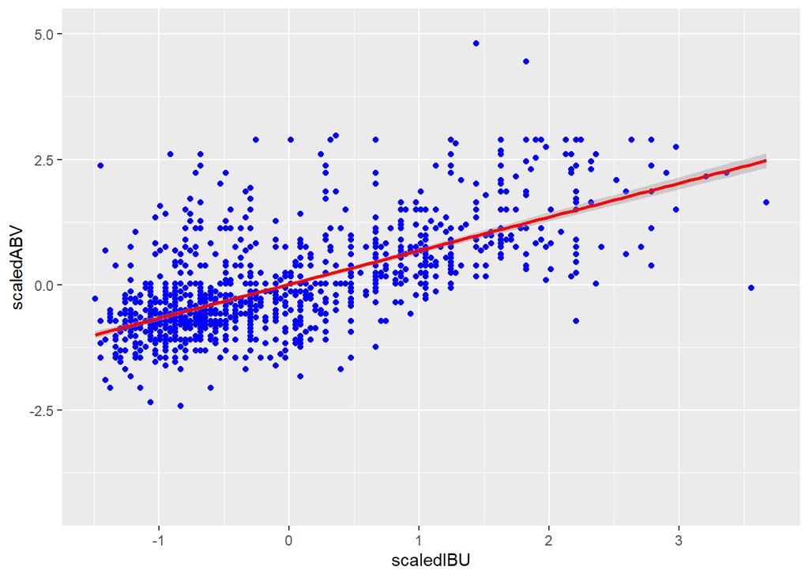

```r
BB_merge %>% ggplot(aes(y=scaledABV, x=scaledIBU)) + geom_point(color='blue') + geom_smooth(method = 'lm',se=TRUE, color = "Red") #+geom_abline(intercept = -2.959529, slope=49.39)
```

## Conclusion: The scatter plot draw above show an apparent relationship between bitterness of the beer and its alcoholic content.

## 8) Budweiser would also like to investigate the difference with respect to IBU and ABV between IPAs (India Pale Ales) and other types of Ale (any beer with “Ale” in its name other than IPA). You decide to use KNN classification to investigate this relationship. Provide statistical evidence one way or the other. You can of course assume your audience is comfortable with percentages … KNN is very easy to understand conceptually.

## In addition, while you have decided to use KNN to investigate this relationship (KNN is required) you may also feel free to supplement your response to this question with any other methods or techniques you have learned. Creativity and alternative solutions are always encouraged.

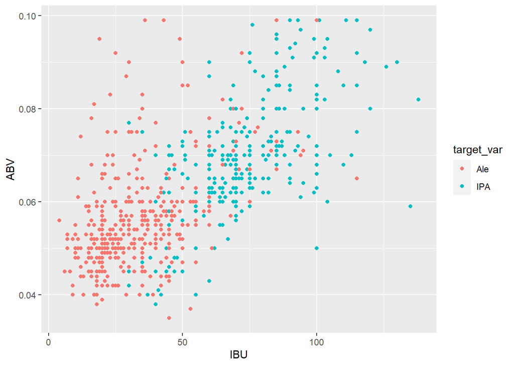

```r
#Filtering out IPA and Ale

BB_merge_mutate <- BB_merge %>% mutate(target_var = ifelse(str_detect(Style,regex(" Ale",ignore_case = T)),"Ale", ifelse(str_detect(Style,regex(" IPA", ignore_case = T)),"IPA",'NA')))
BB_merge_filtered <- BB_merge_mutate %>% filter(target_var != "NA")

BB_merge_filtered <- BB_merge_filtered %>% filter(!is.na(ABV) & !is.na(IBU))

BB_merge_filtered %>% ggplot(aes(x=IBU, y=ABV, color=target_var)) + geom_point()
```

```r
BB_merge_filtered %>% filter(is.na(ABV))
```

```
##  [1] Brewery_id Name.x     Beer_ID    ABV        IBU        Style
##  [7] Ounces     State      Name.y     City       State_Name scaledIBU
## [13] scaledABV  target_var
## <0 rows> (or 0-length row.names)
```

```r
BB_merge_filtered$scaleABV <- scale(BB_merge_filtered$ABV)
BB_merge_filtered$scaleIBU <- scale(BB_merge_filtered$IBU)


IPA <- BB_merge_final[str_detect(BB_merge_final$Style, "IPA"), ]
Ale <- BB_merge_final[str_detect(BB_merge_final$Style, "Ale"), ]

#replace entire name in style with "IPA"

replace_IPA<-IPA %>% mutate(Style = paste0( ifelse(grepl("IPA", Style), "IPA", '')))
#replace entire name in styler with "Ale"
replace_Ale<-Ale %>% mutate(Style = paste0( ifelse(grepl("Ale", Style), "Ale", '')))
total<-rbind(replace_IPA,replace_Ale)
head(total)
```

```
## # A tibble: 6 x 13
## # Groups:   State [3]
##   Brewery_id Name.x    Beer_ID   ABV   IBU Style Ounces State Name.y      City
##        <int> <chr>       <int> <dbl> <int> <chr>  <dbl> <chr> <chr>       <chr>
## 1          1 Get Toge~    2692 0.045    50 IPA       16 MN    "NorthGate~ Minne~
## 2          2 Citra As~    2686 0.08     68 IPA       16 KY    "Against t~ Louis~
## 3          2 Rico Sau~    2678 0.076    68 IPA       16 KY    "Against t~ Louis~
## 4          2 Pile of ~    2675 0.06     65 IPA       16 KY    "Against t~ Louis~
## 5          4 Habitus ~    2668 0.08    100 IPA       16 CA    "Mike Hess~ San D~
## 6          4 Solis        2667 0.075    85 IPA       16 CA    "Mike Hess~ San D~
## # ... with 3 more variables: State_Name <chr>, median_ABV <dbl>,
## #   median_IBU <dbl>
```

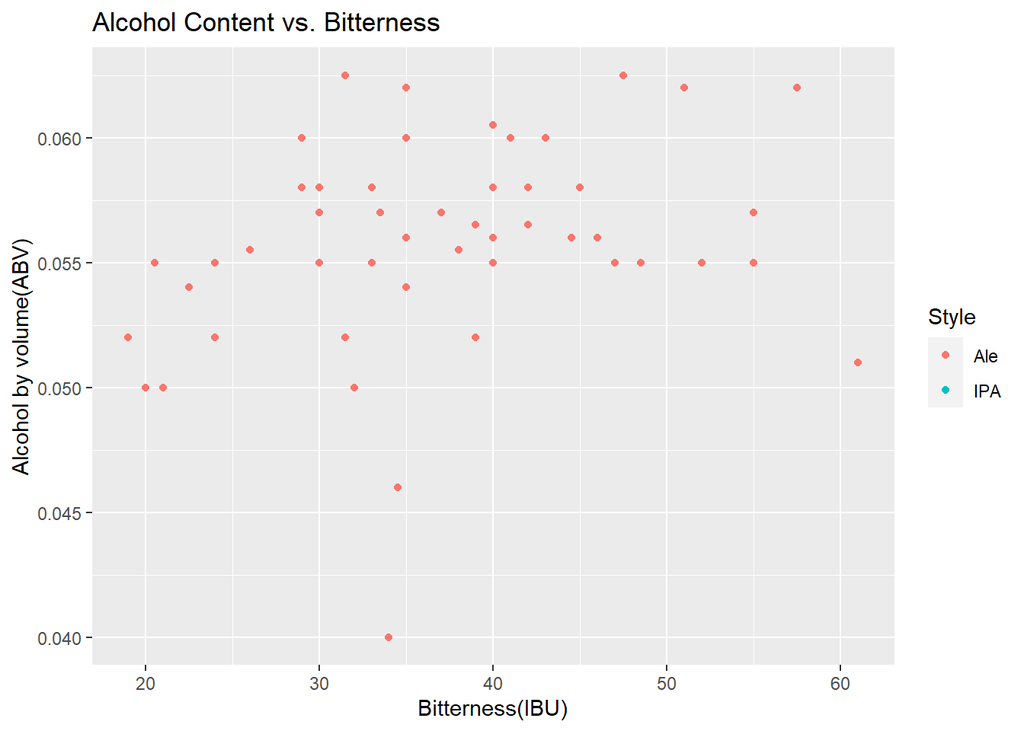

```r
#geom_smooth(method = "lm")+
total%>% ggplot(aes(x = median_IBU, y = median_ABV, color=Style)) + geom_point() +
  ggtitle("Alcohol Content vs. Bitterness") +
  xlab("Bitterness(IBU)") + ylab("Alcohol by volume(ABV)")
```

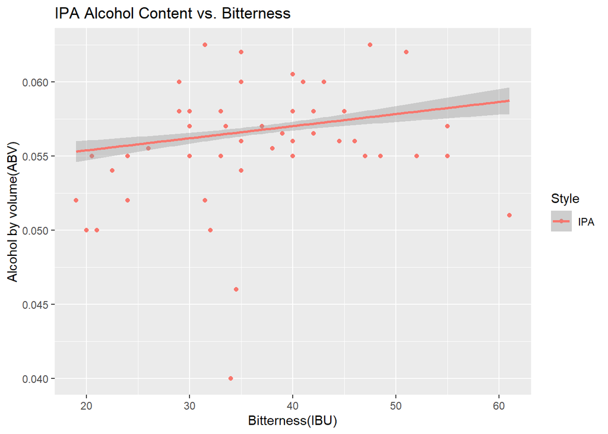

```r
replace_IPA%>% ggplot(aes(x = median_IBU, y = median_ABV, color=Style)) + geom_point() +
  geom_smooth(method = "lm")+
  ggtitle("IPA Alcohol Content vs. Bitterness") +
  xlab("Bitterness(IBU)") + ylab("Alcohol by volume(ABV)")
```

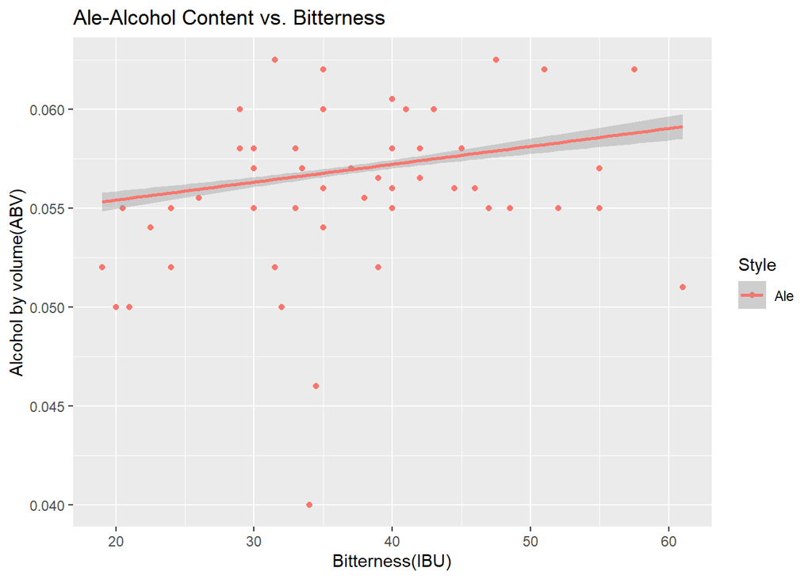

```r
replace_Ale%>% ggplot(aes(x = median_IBU, y = median_ABV, color=Style)) + geom_point() +
  geom_smooth(method = "lm")+
  ggtitle("Ale-Alcohol Content vs. Bitterness") +
  xlab("Bitterness(IBU)") + ylab("Alcohol by volume(ABV)")
```

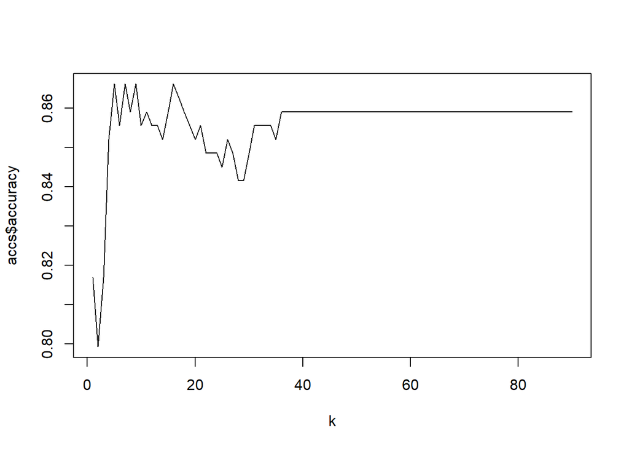

```r
set.seed(6)
splitPerc = .70

total=na.omit(total)#Omit rows with NAs.
trainIndices = sample(1:dim(total)[1],round(splitPerc * dim(total)[1]))
train = total[trainIndices,]
test = total[-trainIndices,]

## Loop for many k and one training / test partition
accs = data.frame(accuracy = numeric(90), k = numeric(90))
for(i in 1:90)
{
  classifications = knn(train[,c(4,5)],test[,c(4,5)],train$Style, prob = TRUE, k = i)
  table(test$Style,classifications)
  CM = confusionMatrix(table(test$Style,classifications))
  accs$accuracy[i] = CM$overall[1]
  accs$k[i] = i
}
plot(accs$k,accs$accuracy, type = "l", xlab = "k")
```

```r
#CM
classifications = knn(train[,c(4,5)],test[,c(4,5)],train$Style, prob = TRUE, k = 35)
table(classifications,test$Style)
```

```
##
## classifications Ale IPA
##             Ale 154  25
##             IPA  17  88
```

```r
confusionMatrix(table(classifications,test$Style))
```

```
## Confusion Matrix and Statistics
##
##
## classifications Ale IPA
##             Ale 154  25
##             IPA  17  88
##
##                Accuracy : 0.8521
##                  95% CI : (0.8054, 0.8913)
##     No Information Rate : 0.6021
##     P-Value [Acc > NIR] : <2e-16
##
##                   Kappa : 0.6876
##
##  Mcnemar's Test P-Value : 0.2801
##
##             Sensitivity : 0.9006
##             Specificity : 0.7788
##          Pos Pred Value : 0.8603
##          Neg Pred Value : 0.8381
##              Prevalence : 0.6021
##          Detection Rate : 0.5423
##    Detection Prevalence : 0.6303
##       Balanced Accuracy : 0.8397
##
##        'Positive' Class : Ale
##
```

## Conclusion: The above analysis show a lot more of IBU beers of types IPA compare to type Ale

## 9) Knock their socks off! Find one other useful inference from the data that you feel Budweiser may be able to find value in. You must convince them why it is important and back up your conviction with appropriate statistical evidence.

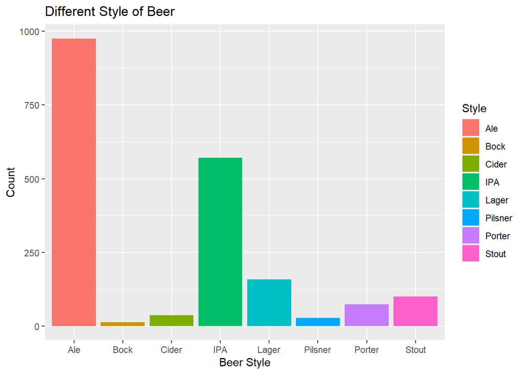

```r
#Which style of beer occurs most?

Lager <- BB_merge_final[str_detect(BB_merge_final$Style, "Lager"), ]
Porter <- BB_merge_final[str_detect(BB_merge_final$Style, "Porter"), ]
Stout <- BB_merge_final[str_detect(BB_merge_final$Style, "Stout"), ]
Bock <- BB_merge_final[str_detect(BB_merge_final$Style, "Bock"), ]
Cider <- BB_merge_final[str_detect(BB_merge_final$Style, "Cider"), ]
Pilsner <- BB_merge_final[str_detect(BB_merge_final$Style, "Pilsner"), ]

replace_Lager<-Lager %>% mutate(Style = paste0( ifelse(grepl("Lager", Style), "Lager", '')))
replace_Porter<-Porter %>% mutate(Style = paste0( ifelse(grepl("Porter", Style), "Porter", '')))
replace_Stout<-Stout %>% mutate(Style = paste0( ifelse(grepl("Stout", Style), "Stout", '')))
replace_Bock<-Bock %>% mutate(Style = paste0( ifelse(grepl("Bock", Style), "Bock", '')))
replace_Cider<-Cider %>% mutate(Style = paste0( ifelse(grepl("Cider", Style), "Cider", '')))
replace_Pilsner<-Pilsner %>% mutate(Style = paste0( ifelse(grepl("Pilsner", Style), "Pilsner", '')))

other<-rbind(replace_IPA,replace_Ale,replace_Lager,replace_Porter,replace_Stout,replace_Bock,replace_Cider,replace_Pilsner)

other %>% ggplot(aes(x=Style, fill=Style),stat='count')+
    geom_bar()+
    ggtitle('Different Style of Beer')+
    xlab('Beer Style')+ylab('Count')
```

## Conclusion: The above finding show that whith a big concentration of ALE type of beers follow by the IPA type of beers